# Homework 11

Angela McMahon

4/12/2026

### Frequency Table of all Origin/Destination Pairs

```r
flight_count <-flights%>%
  count(origin, dest)
flight_count%>%
  head(n=6)%>%
  kable()
```

| origin | dest | n |
| --- | --- | --- |
| EWR | ALB | 439 |
| EWR | ANC | 8 |
| EWR | ATL | 5022 |
| EWR | AUS | 968 |
| EWR | AVL | 265 |
| EWR | BDL | 443 |

Using the flights data set, counted the origin and destination pairs. Displayed frequency table of first 6 rows. [^1]

### Joining Flights and Airports Data sets by Origin Lat. and Long.

```r
flight_ap <- flight_count%>%
  left_join(airports%>%select(faa, lat, lon), join_by(origin== faa))%>%
  rename(origin_lat= lat, origin_long= lon)%>%
  relocate(origin_lat, origin_long, .after=origin)
flight_ap%>%
  head(n=6)%>%
  kable()
```

| origin | origin_lat | origin_long | dest | n |
| --- | --- | --- | --- | --- |
| EWR | 40.6925 | -74.16867 | ALB | 439 |
| EWR | 40.6925 | -74.16867 | ANC | 8 |
| EWR | 40.6925 | -74.16867 | ATL | 5022 |
| EWR | 40.6925 | -74.16867 | AUS | 968 |
| EWR | 40.6925 | -74.16867 | AVL | 265 |
| EWR | 40.6925 | -74.16867 | BDL | 443 |

Left joined the previously stored data set with the airports data set. Inside of this selected only the latitude, longitude, and faa columns from the airports data set. Joined the data sets by origin which is also faa in airports. Renamed latitude and longitude to specify as origin latitude and origin longitude. Relocated both the lat. and long. columns to be after the origin column. Stored this, then displayed the first 6 rows of the data set as a table. [^2]

### Joining Flights and Aiports by Destination Lat. and Long.

```r
flight_ap2 <-flight_ap%>%
  left_join(airports%>%select(faa, lat, lon), join_by(dest==faa))%>%
  rename(dest_lat=lat, dest_long=lon)%>%
  relocate(dest_lat, dest_long, .after=dest)

flight_ap2%>%
  head(n=6)%>%
  kable()
```

| origin | origin_lat | origin_long | dest | dest_lat | dest_long | n |
| --- | --- | --- | --- | --- | --- | --- |
| EWR | 40.6925 | -74.16867 | ALB | 42.74827 | -73.80169 | 439 |
| EWR | 40.6925 | -74.16867 | ANC | 61.17436 | -149.99636 | 8 |
| EWR | 40.6925 | -74.16867 | ATL | 33.63672 | -84.42807 | 5022 |
| EWR | 40.6925 | -74.16867 | AUS | 30.19453 | -97.66989 | 968 |
| EWR | 40.6925 | -74.16867 | AVL | 35.43619 | -82.54181 | 265 |
| EWR | 40.6925 | -74.16867 | BDL | 41.93889 | -72.68322 | 443 |

Took the stored, joined data and left joined this with the airports data set again. However, after selecting for lat., long., and faa, we joined by destination equal to faa. Once again renamed to be representative of destination lat. and destination long. Relocated the columns to be after the destination column. After storing this, displayed a table of the first 6 rows. [^3]

### Map of the United States

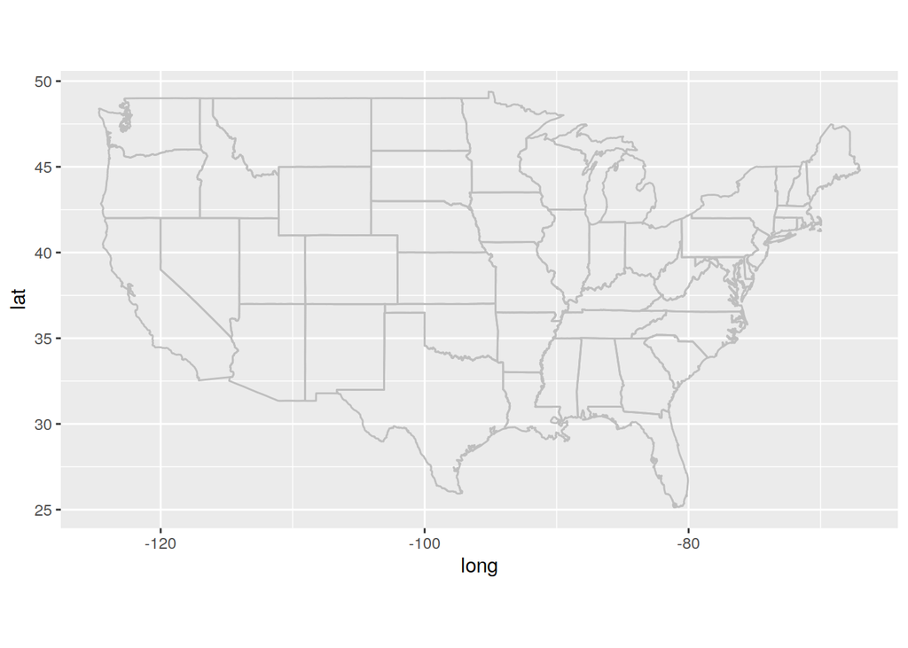

```r
ggplot() +
geom_polygon(
data = map_data("state") ,
mapping = aes(x = long, y = lat, group = group),
fill = NA, color = "gray"
) +
coord_fixed(1.3)
```

Imported map of United States.  
[^4]

### Map of the United States with Flight Origins to Destinations

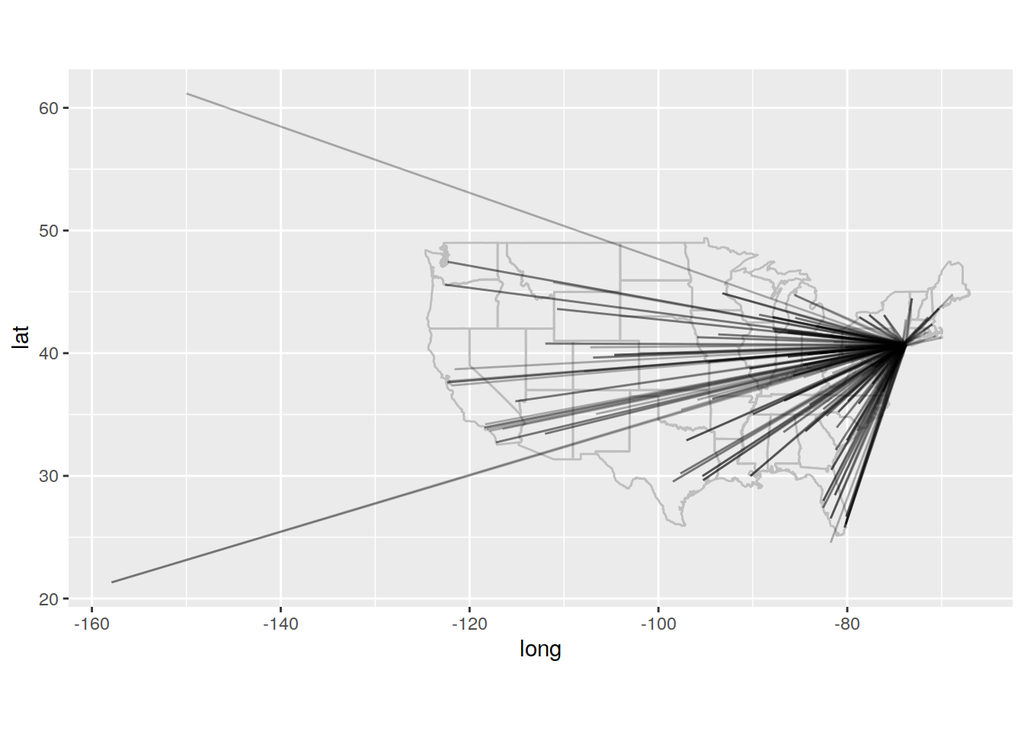

```r
ggplot() +
geom_polygon(
data = map_data("state") ,
mapping = aes(x = long, y = lat, group = group),
fill = NA, color = "gray"
) +
coord_fixed(1.3)+geom_segment(data = flight_ap2, mapping = aes(x=origin_long, y=origin_lat, xend=dest_long, yend=dest_lat), alpha=0.3)
```

Previous map, layered with the flight frequency table that includes all origin and destination latitudes and longitudes. We can see the flights that leave the US have a destination on the left of the plot. We can see the color is heavily concentrated on the East coast indicating most flights are going along that path. [^5]

### Map of U.S. FLight Patters with only Destinations in the Country

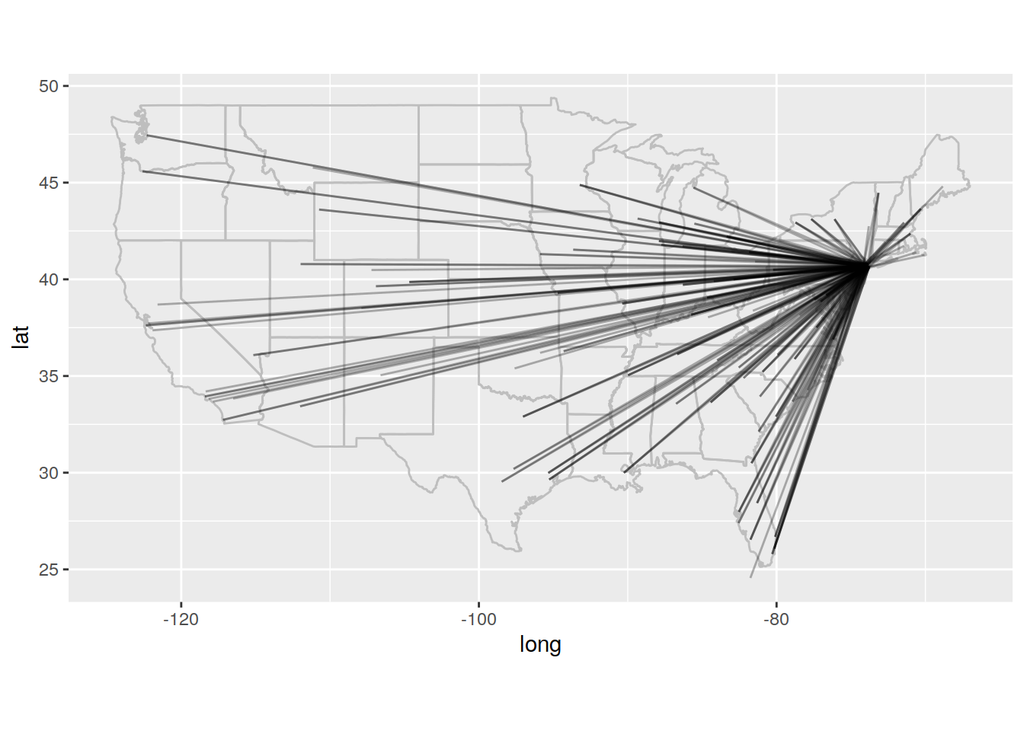

```r
flights_map <- flight_ap2%>%
  filter(dest_long>-130)
ggplot() +
geom_polygon(
data = map_data("state") ,
mapping = aes(x = long, y = lat, group = group),
fill = NA, color = "gray"
) +
coord_fixed(1.3)+geom_segment(data = flights_map, mapping = aes(x=origin_long, y=origin_lat, xend=dest_long, yend=dest_lat), alpha=0.3)
```

Removed the flights that have a destination outside of the United States. Displayed the new map. Now we can better see the distribution of flights across the United States. The flights are still heavily concentrated on the East Coast. But we can also see specific states have a higher frequency of flights landing at them then others. [^6]

[^1]: Question 1 completed.
[^2]: Question 2 completed.
[^3]: Question 3 completed.
[^4]: Question 4 completed.
[^5]: Question 5 completed.
[^6]: Question 6 completed.